# Stratification

```r
eigengenes <- readRDS("clean_data/3_iterative_WGCNA_cleaning/mayo_eigengenes.RDS")

module.names <- readRDS("clean_data/3_iterative_WGCNA_cleaning/mayo_submodule_labels.RDS")
module.names <- unlist(module.names)

sig.genes <- readRDS("clean_data/3_iterative_WGCNA_cleaning/mayo_submodule_sig_genes.RDS")

cleaned <- readRDS("clean_data/1_mayo_cleaning/mayo_cleaned.RDS")

# Separate into cases and controls
eigengenes.cases <- eigengenes[eigengenes$Diagnosis=="AD",]
eigengenes.controls <- eigengenes[eigengenes$Diagnosis=="CONTROL",]
```

## Generate Matrix of Submodule Eigengenes

Here I created a matrix of eigengene expression data. I created separate matrices for cases and controls as well as a combined expression matrix.

```r
# Eigengene expression of cases
module.vecs.cases <- eigengenes.cases[,module.names]
# Eigengene expression of controls and MCIs
module.vecs.controls <- eigengenes.controls[,module.names]
# Total eigengene expression
module.vecs <- eigengenes[,module.names]
```

## Cluster Analysis

I performed cluster analysis on the eigengene expression data. I used the `NbClust` package, which uses democratized results across 30 different mathematical indices to determine the optimal number of clusters. I tested one reallocation method - K-Means - and three agglomerative methods - Ward D2, McQuitty (WPGMA), and Average (UPGMA). I used silhouettes as a method of determining the optimal clustering strategy. I used Tukey’s Biweight to determine relations between patients rather than Pearson correlations or Euclidean distances since Tukey’s Biweight is considered a robust metric.

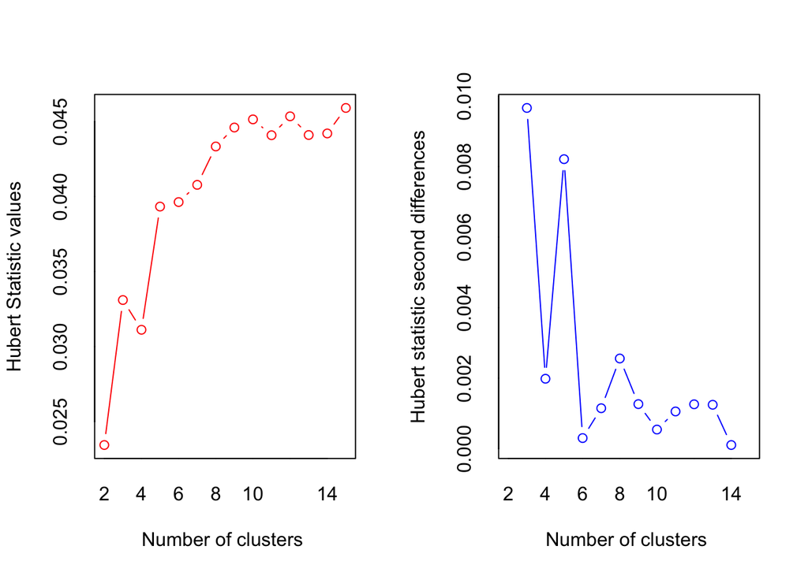

```
## *** : The Hubert index is a graphical method of determining the number of clusters.
##                 In the plot of Hubert index, we seek a significant knee that corresponds to a
##                 significant increase of the value of the measure i.e the significant peak in Hubert
##                 index second differences plot.
##
```

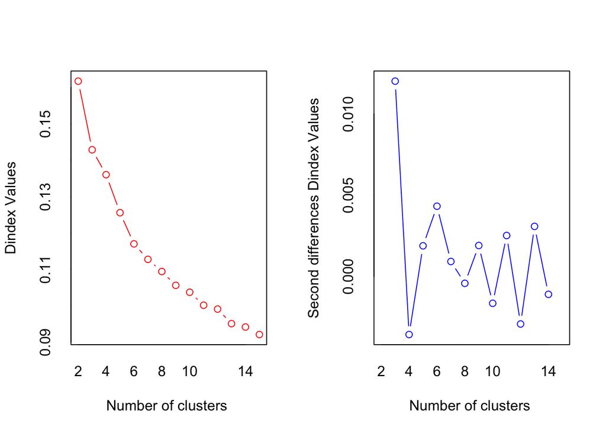

```
## *** : The D index is a graphical method of determining the number of clusters.
##                 In the plot of D index, we seek a significant knee (the significant peak in Dindex
##                 second differences plot) that corresponds to a significant increase of the value of
##                 the measure.
##
## * Among all indices:
## * 5 proposed 2 as the best number of clusters
## * 12 proposed 3 as the best number of clusters
## * 2 proposed 7 as the best number of clusters
## * 1 proposed 11 as the best number of clusters
## * 1 proposed 13 as the best number of clusters
## * 2 proposed 15 as the best number of clusters
##
##                    ***** Conclusion *****
##
## * According to the majority rule, the best number of clusters is  3
##
##
```

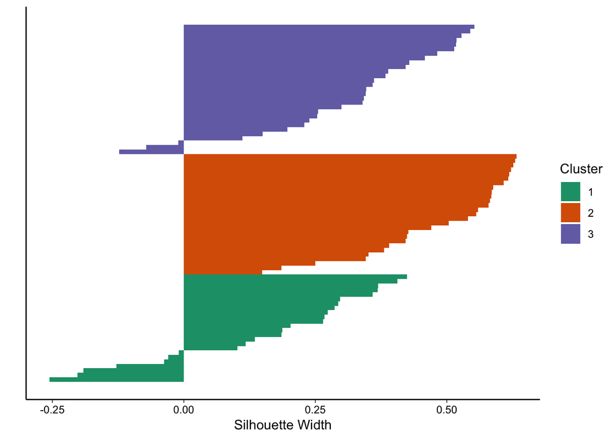

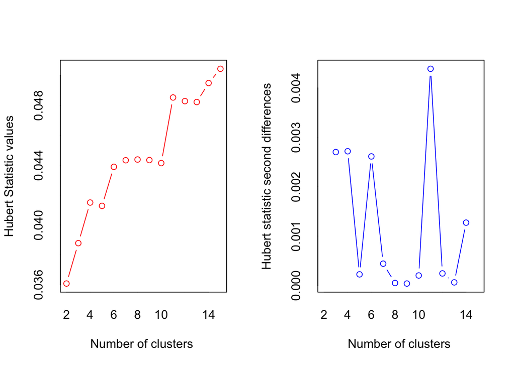

```
## *** : The Hubert index is a graphical method of determining the number of clusters.
##                 In the plot of Hubert index, we seek a significant knee that corresponds to a
##                 significant increase of the value of the measure i.e the significant peak in Hubert
##                 index second differences plot.
##
```

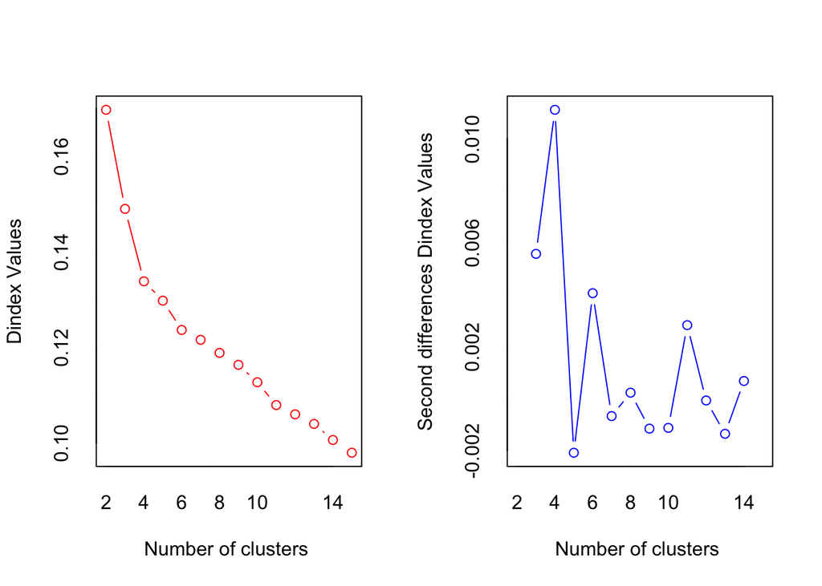

```
## *** : The D index is a graphical method of determining the number of clusters.
##                 In the plot of D index, we seek a significant knee (the significant peak in Dindex
##                 second differences plot) that corresponds to a significant increase of the value of
##                 the measure.
##
## * Among all indices:
## * 1 proposed 2 as the best number of clusters
## * 4 proposed 3 as the best number of clusters
## * 11 proposed 4 as the best number of clusters
## * 1 proposed 5 as the best number of clusters
## * 1 proposed 6 as the best number of clusters
## * 1 proposed 9 as the best number of clusters
## * 1 proposed 10 as the best number of clusters
## * 1 proposed 11 as the best number of clusters
## * 1 proposed 12 as the best number of clusters
## * 1 proposed 13 as the best number of clusters
##
##                    ***** Conclusion *****
##
## * According to the majority rule, the best number of clusters is  4
##
##
```

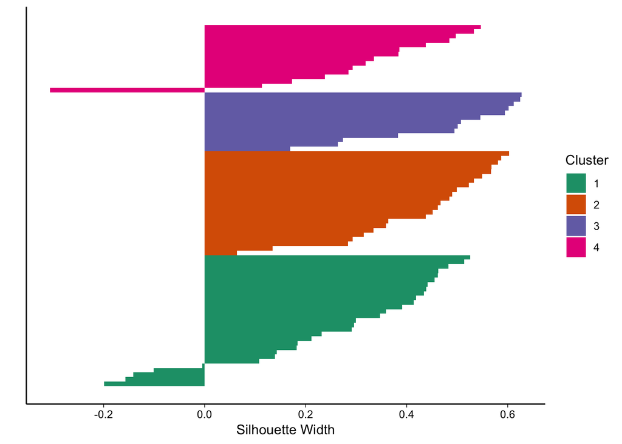

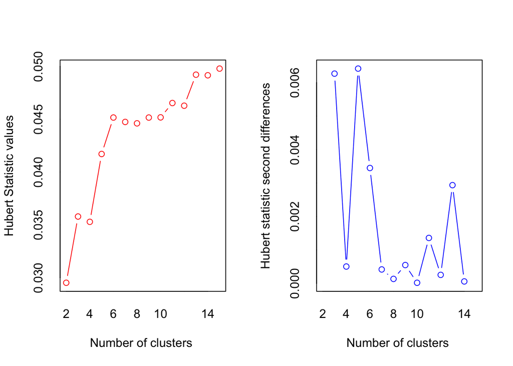

```
## *** : The Hubert index is a graphical method of determining the number of clusters.
##                 In the plot of Hubert index, we seek a significant knee that corresponds to a
##                 significant increase of the value of the measure i.e the significant peak in Hubert
##                 index second differences plot.
##
```

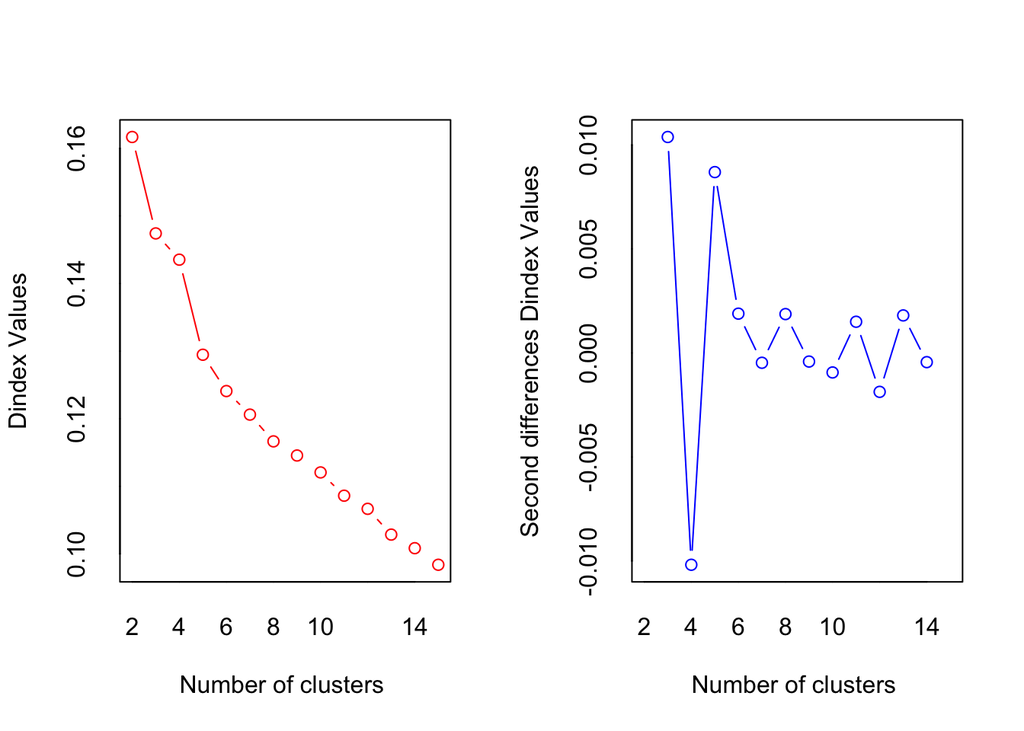

```
## *** : The D index is a graphical method of determining the number of clusters.
##                 In the plot of D index, we seek a significant knee (the significant peak in Dindex
##                 second differences plot) that corresponds to a significant increase of the value of
##                 the measure.
##
## * Among all indices:
## * 3 proposed 2 as the best number of clusters
## * 8 proposed 3 as the best number of clusters
## * 1 proposed 4 as the best number of clusters
## * 5 proposed 5 as the best number of clusters
## * 2 proposed 6 as the best number of clusters
## * 1 proposed 9 as the best number of clusters
## * 2 proposed 10 as the best number of clusters
## * 1 proposed 15 as the best number of clusters
##
##                    ***** Conclusion *****
##
## * According to the majority rule, the best number of clusters is  3
##
##
```

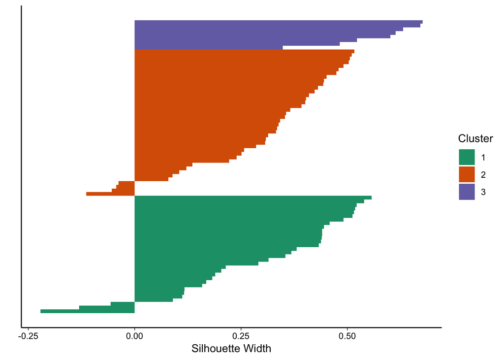

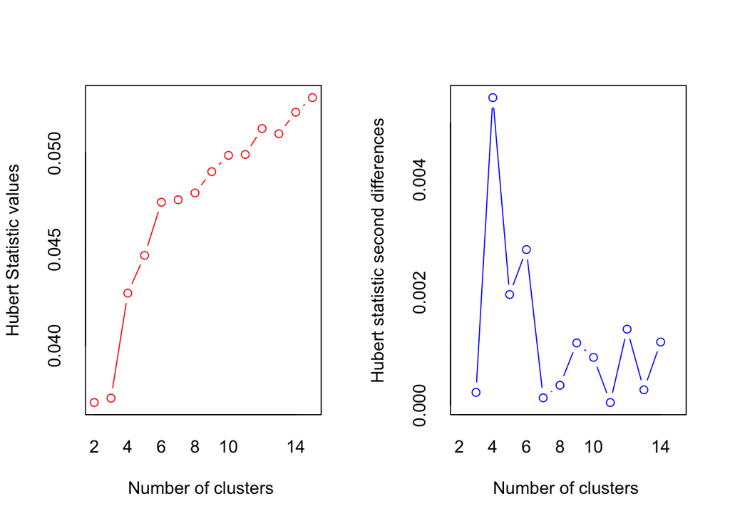

```
## *** : The Hubert index is a graphical method of determining the number of clusters.
##                 In the plot of Hubert index, we seek a significant knee that corresponds to a
##                 significant increase of the value of the measure i.e the significant peak in Hubert
##                 index second differences plot.
##
```

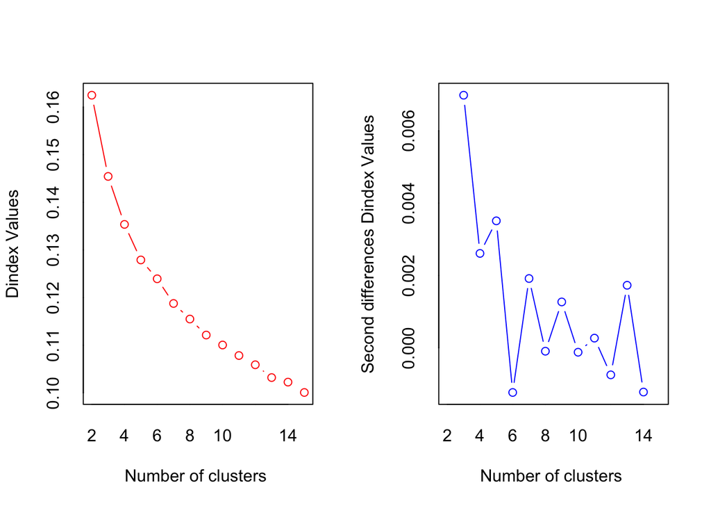

```
## *** : The D index is a graphical method of determining the number of clusters.
##                 In the plot of D index, we seek a significant knee (the significant peak in Dindex
##                 second differences plot) that corresponds to a significant increase of the value of
##                 the measure.
##
## * Among all indices:
## * 4 proposed 2 as the best number of clusters
## * 8 proposed 3 as the best number of clusters
## * 5 proposed 4 as the best number of clusters
## * 2 proposed 5 as the best number of clusters
## * 1 proposed 12 as the best number of clusters
## * 2 proposed 13 as the best number of clusters
## * 1 proposed 14 as the best number of clusters
##
##                    ***** Conclusion *****
##
## * According to the majority rule, the best number of clusters is  3
##
##
```

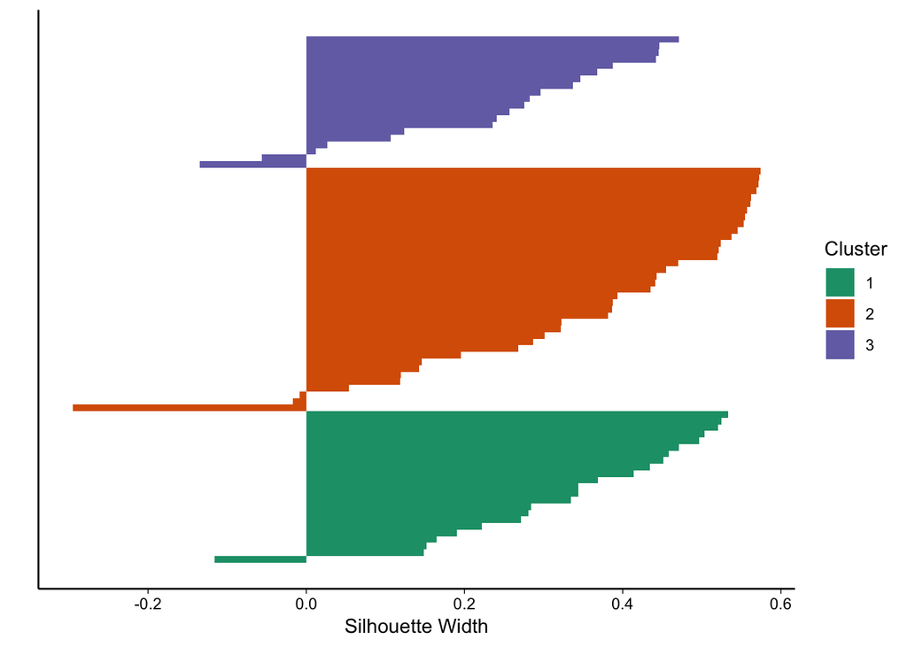

```r
# Generate a distance matrix based on Tukey's Biweight
tukey.dist <- dist(biwt.cor(module.vecs.cases))

# Methods tested
methods <- c("kmeans", "average", "mcquitty", "ward.D2")
nbc.res <- list()

for (m in methods) {

  nbc.res[[m]] <- NbClust(
    module.vecs.cases,
    diss=tukey.dist,
    distance=NULL,
    min.nc=2,
    max.nc=15,
    method=m,
    index="all"
  )

  s <- silhouette(nbc.res[[m]]$Best.partition, tukey.dist)
  s.m <- data.frame(matrix(as.vector(s), nrow=nrow(s)))
  colnames(s.m) <- dimnames(s)[[2]]
  s.m <- s.m %>%
    dplyr::arrange(cluster, sil_width) %>%
    dplyr::mutate(ID=1:nrow(s))
  s.m$cluster <- as.factor(s.m$cluster)
  print(
    ggplot(s.m) +
      geom_bar(aes(x=ID, y=sil_width, fill=cluster), stat="identity", width=1) +
      scale_fill_brewer(palette="Dark2") +
      labs(x="", y="Silhouette Width", fill="Cluster") +
      coord_flip() +
      basic_theme_big +
      theme(axis.text.y=element_blank(), axis.ticks.y=element_blank())
  )
  ggsave(paste0("results/4_stratification/silhouette_", m, ".svg"), width=8, height=8)
}
```

Looking at the results, I decided to use Ward D2 since it has the best silhouette results. The methods predicted 3-4 clusters.

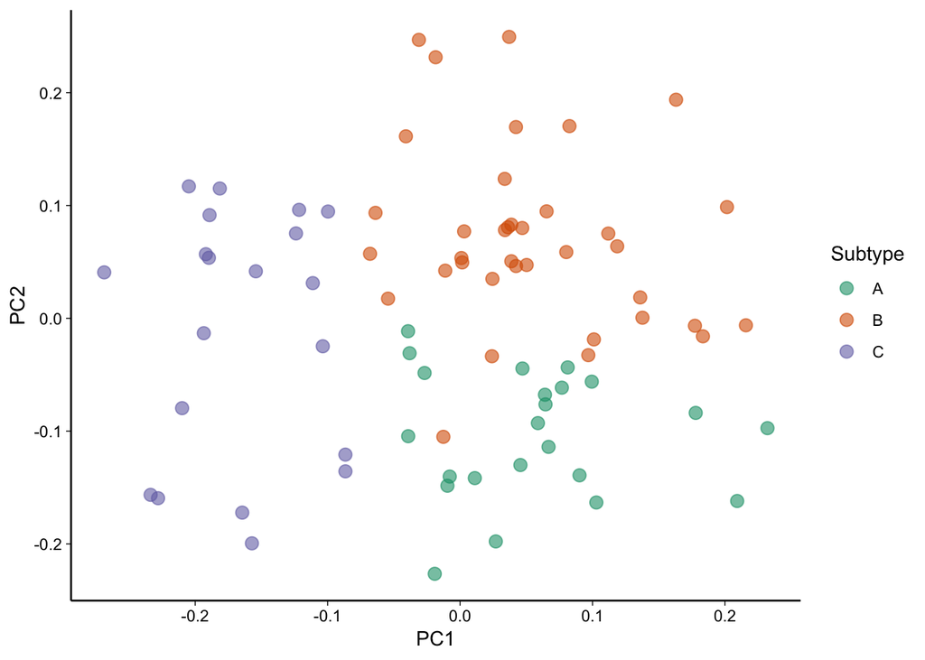

```r
# Choose K-Means for the rest of the analysis
nbc.res <- nbc.res[["ward.D2"]]
names(nbc.res$Best.partition) <- rownames(module.vecs.cases)

# Create a patient to subtype map
subtypes <- data.frame(
  Patient=rownames(module.vecs),
  Subtype=c("A", "B", "C")[as.numeric(nbc.res$Best.partition[rownames(module.vecs)])],
  stringsAsFactors=F
)
subtypes$Subtype[is.na(subtypes$Subtype)] = "Control"
subtypes$Subtype <- factor(subtypes$Subtype, levels=c("A", "B", "C", "Control"))
rownames(subtypes) <- subtypes$Patient

saveRDS(nbc.res, "clean_data/4_stratification/mayo_clustering.RDS")
saveRDS(subtypes, "clean_data/4_stratification/mayo_subtypes_map.RDS")

# Run PCA to splay our data
pca <- prcomp(module.vecs.cases)
plot.data <- as.data.frame(pca$x[,1:2])
plot.data$Subtype <- subtypes[rownames(plot.data),"Subtype"]

ggplot(data=plot.data) +
  geom_point(aes(PC1, PC2, color=Subtype), size=I(3), alpha=0.6) +
  guides(color=guide_legend(title="Subtype")) +
  scale_color_brewer(palette="Dark2") +
  guides(size=FALSE) +
  basic_theme_big
```

```r
ggsave(filename="results/4_stratification/mayo_clustering.svg", width=8, height=7.5)
```

## Stratification Matrix

I use a heatmap-like matrix to demonstrate how the eigengenes associate with specific subtypes generated in the clustering process.

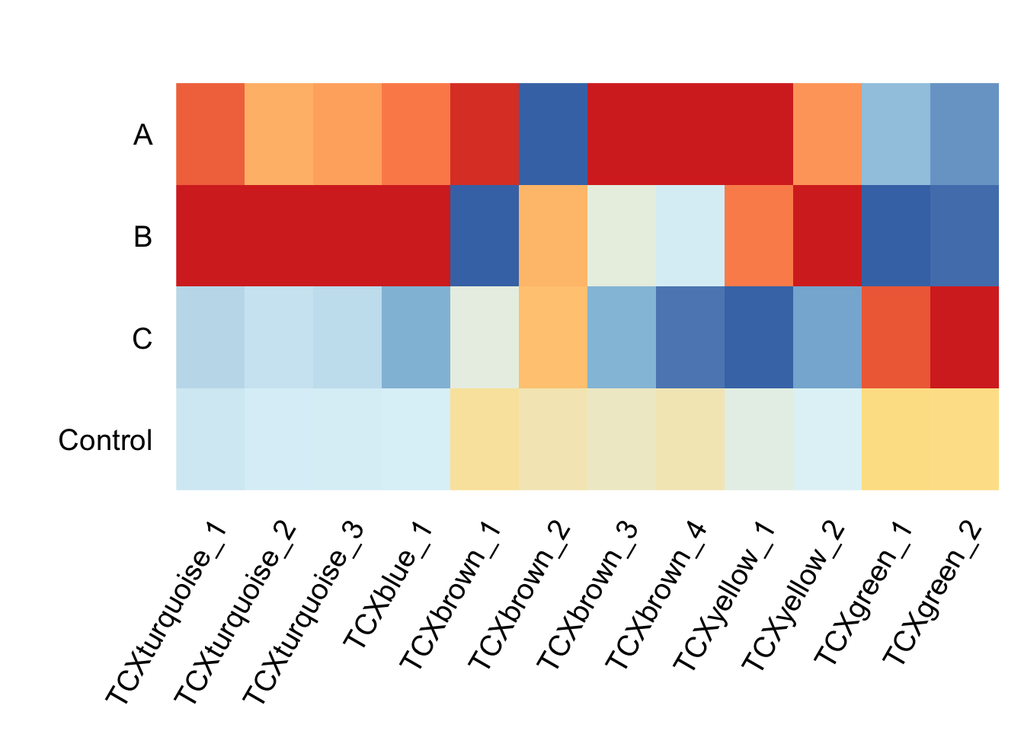

```r
strat.mtx <- do.call(rbind,
  lapply(
    split(module.vecs[subtypes$Patient,], subtypes$Subtype),
    function(x) apply(x, 2, mean)
  )
)
strat.mtx <- strat.mtx[nrow(strat.mtx):1,]
strat.mtx <- t(apply(strat.mtx, 1, function(x) x / apply(abs(strat.mtx), 2, max)))

p <- plot.strat(strat.mtx, main="", xlab="", ylab="", text=F)
p$layers <- p$layers[1]
p <- p + guides(fill=F) +
  theme(
    axis.ticks.x=element_blank(),
    axis.ticks.y=element_blank(),
    panel.grid.major=element_blank(),
    panel.border=element_blank()
  )
print(p)
```

```r
ggsave(file="results/4_stratification/subtypes_heatmap.svg", plot=p, width=12, height=5)
```

## Covariate Analysis

I tested if any covariates were enriched in any given subtype and may explain the variation in gene expression that led to the subtyping.

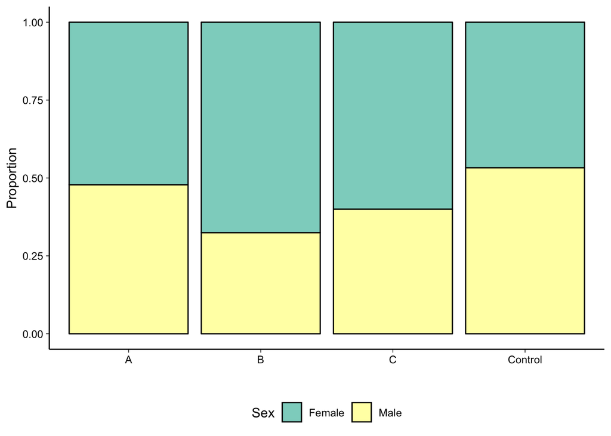

```r
# Sex
trait <- factor(c("Female", "Male")[cleaned[rownames(subtypes),"Sex"]], levels=c("Female", "Male"))
plot.data <- subtypes
plot.data$Trait <- trait
ggplot(data=na.omit(plot.data)) +
  geom_bar(aes(x=Subtype, fill=Trait), position=position_fill(), color="black") +
  scale_fill_brewer(palette="Set3") +
  labs(x="", y="Proportion", fill="Sex") +
  basic_theme_big +
  theme(legend.position="bottom")
```

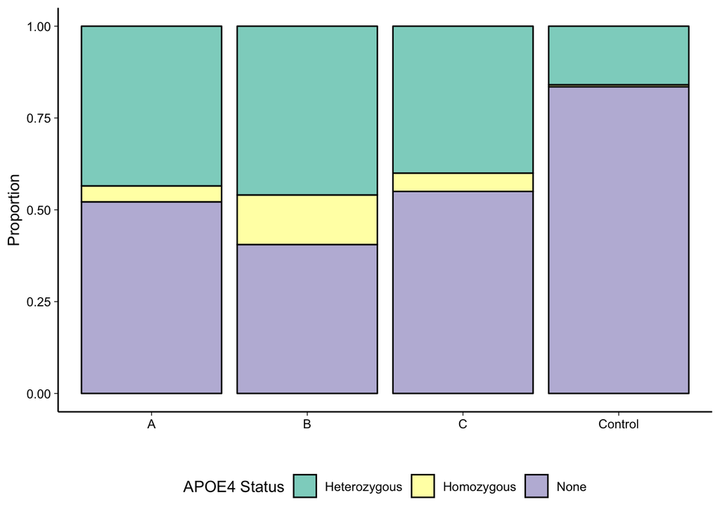

```r
ggsave(filename="results/4_stratification/trait_sex_by_subtype.svg", width=7, height=7)

# APOE4 Status
trait <- factor(c("None", "Heterozygous", "Homozygous")[as.numeric(cleaned[rownames(subtypes),"Tissue.APOE4"])-3])
plot.data <- subtypes
plot.data$Trait <- trait
ggplot(data=na.omit(plot.data)) +
  geom_bar(aes(x=Subtype, fill=Trait), position=position_fill(), color="black") +
  scale_fill_brewer(palette="Set3") +
  labs(x="", y="Proportion", fill="APOE4 Status") +
  basic_theme_big +
  theme(legend.position="bottom")
```

```r
ggsave(filename="results/4_stratification/trait_apoe4_by_subtype.svg", width=7, height=7)
```

## Generating Data for EMMAX

I generated the submodule specificity metric here. I save it for future use in R as well as files that follow PLINK standards to run through EMMAX.

```r
subs <- as.character(unique(subtypes$Subtype[subtypes$Subtype %in% LETTERS]))
subs <- subs[ordered(subs)]

centroids <- lapply(
  split(module.vecs[subtypes$Patient,], subtypes$Subtype)[subs],
  function(x) { apply(x, 2, mean) }
)
patient.subtypes <- as.data.frame(cbind(
  rownames(module.vecs),
  as.character(subtypes[rownames(module.vecs),"Subtype"]),
  do.call(
    cbind,
    lapply(
      centroids,
      function(x) module.vecs %>%
        apply(., 1, function(v) sqrt(sum((x-v)^2)))
    )
  )
))
colnames(patient.subtypes) <- c("Patient", "Subtype", "A", "B", "C")
patient.subtypes$A <- as.numeric(as.character(patient.subtypes$A))
patient.subtypes$B <- as.numeric(as.character(patient.subtypes$B))
patient.subtypes$C <- as.numeric(as.character(patient.subtypes$C))

saveRDS(patient.subtypes, "clean_data/4_stratification/mayo_patient_subtypes.RDS")
```

I generated the `.pheno` file required specifically by EMMAX.

```r
# Load mapping from RNA Seq IDs to WGS IDs
mayo.ids <- read.csv("raw_data/AMP-AD_Mayo_WGS_covariates.csv", stringsAsFactors=F)

# Load EMMAX .tfam file and order data by expected patients
tfam <- read.table("raw_data/Mayo_allSNPjointMAF05_Clean__TRANSPOSED_EMMAX.tfam")
colnames(tfam) <- c("Family", "WGS.ID", "X1", "X2", "X3", "X4")

# Merge data into subtype map by RNA Seq IDs
emmax.pheno <- merge(subtypes, mayo.ids, by.x="Patient", by.y="RNAseq_TCX_SampleID") %>%
  dplyr::select(Patient, Subtype, WGS.ID=WGS_Participant_ID) %>%
  dplyr::filter(Patient %in% subtypes$Patient) %>%
  unique

# Merge data into patient subtype specificity metric data
emmax.pheno <- merge(emmax.pheno, patient.subtypes, by.x="Patient", by.y="Patient") %>%
  dplyr::select(Patient, Subtype=Subtype.x, WGS.ID, A, B, C) %>%
  dplyr::filter(Patient %in% subtypes$Patient) %>%
  unique

# Merge data into eigengenes
emmax.pheno <- merge(emmax.pheno, eigengenes, by.x="Patient", by.y="Patient") %>%
  dplyr::select(Patient, Subtype, WGS.ID, A, B, C, module.names) %>%
  dplyr::filter(Patient %in% subtypes$Patient) %>%
  unique

# Remove any patients without WGS ID's (were not sequenced)
mask <- emmax.pheno$WGS.ID != ""& !is.na(emmax.pheno$WGS.ID)
emmax.pheno <- emmax.pheno[mask,]

# Align to TFAM file
emmax.pheno <- merge(tfam, emmax.pheno, by.x="WGS.ID", by.y="WGS.ID", all.x=T) %>%
  dplyr::select(c("WGS.ID", "A", "B", "C", module.names))
rownames(emmax.pheno) <- emmax.pheno$WGS.ID
emmax.pheno <- emmax.pheno[as.character(tfam$WGS.ID),]

# Create EMMAX format file
# 1. Patient Family ID (same as patient ID since unrelated)
# 2. Patient ID
# 3. Phenotype
wgs.id <- as.character(emmax.pheno$WGS.ID)
emmax.pheno <- emmax.pheno %>%
  dplyr::select(c("A", "B", "C", module.names))
for (pheno in colnames(emmax.pheno)) {
  write.table(
    cbind(wgs.id, wgs.id, emmax.pheno[,pheno]),
    file=paste0("clean_data/4_stratification/emmax_phenotypes/", pheno, ".pheno"),
    quote=F, sep="\t", row.names=F, col.names=F
  )
}
```